# act_report

## Report: act_report

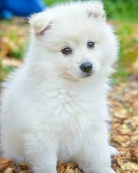

### Communicate Insights:

2.Top 10 dog breeds with the highest dogs rating

3.Top 10 dog breeds with the highest favorite_count

Firstly,matplotlip.pyploy as plt needs to be imported along a dependant **%matplotlib inline** majorly used for creating plot in python(Jupyter_notebook).

### Steps for Insight 1:

- Created a variable called **top_10_dogBreed_by_retweetCount** which is equivalent to twitter_archive_master dataset
- Retweet_counts was sorted in descending order from *largest to lowest*
- Showing just two columns which are **animal_breed1' and 'retweet_count** for just the first 10 using .head() functions.
- Set and Reset index for animal_breed and make inplace = True.

### Steps for Visuals 1

- The Created variable **top_10_dogBreed_by_retweetCount** is called back using an built-in plot function to plot a bar-chart in an horizontal manner.
- Using a plt function to Create:

  1.Title

  2.ylabel

  3.xlabel and legend automatically created.

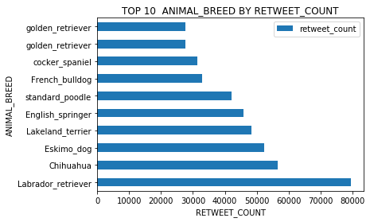

#### Insight #2:.Top 10 dog breeds with the highest rating:

From this insight single-variable (1d) between dog breeds and Rating_numerator.

### Steps for Insight 2:

- Created a variable called **top_10_dogBreed_by_highestRating** which is equivalent to twitter_archive_master dataset
- rating_numerator was sorted in descending order from *largest to lowest*
- Showing just two columns which are **animal_breed1' and 'dogs_ratings** for just the first 10 using .head() functions.
- Set and Reset index for animal_breed and make inplace = True.

  2.ylabel

  3.xlabel and legend automatically created.

#### Insight #3:Top 10 dog breeds with the highest favorite_count:

From this insight single-variable (1d) between dog breeds and highest favorite_count.

### Steps for Insight 3:

- Created a variable called **top_10_dogBreed_by_highest_favorite_count** which is equivalent to twitter_archive_master dataset
- favorite_count was sorted in descending order from *largest to lowest*
- Showing just two columns which are **animal_breed1' and 'favorite_count** for just the first 10 using .head() functions.
- Set and Reset index for animal_breed and make inplace = True.

  2.ylabel

  3.xlabel and legend automatically created.